# GSS Multiple Logistic Regression

```r
GSSslim<-read.csv("../Data/GSSslim11.csv", header=TRUE, stringsAsFactors = FALSE)

GSSguns<-subset(GSSslim, gunlaw==2 | gunlaw==1)

GSSguns$Oppose<-GSSguns$gunlaw-1


GSSguns$Female<-GSSguns$gender1-1

GSSguns<-GSSguns[c("age","Oppose","Female")]
```

### Overview

[GSS Dataset](http://sda.berkeley.edu/sdaweb/analysis/?dataset=gss12)

### Analysis

For this analysis, I will explore this question:

Can a person’s age and gender predict how they feel about requiring a permit to buy a gun?

**AGE** Respondents Age

**Oppose** Would you favor or oppose a law which would require a person to obtain a police permit before he or she could buy a gun?

0. Favor
1. Oppose

**Female** Head of Household

0. Male
1. Female

Here is the data I will be using:

```r
datatable(GSSguns, extensions = "Responsive",options=list(lengthMenu = c(10,25,68)))
```

|  | age | Oppose | Female |
| --- | --- | --- | --- |
| 1 | 22 | 1 | 0 |
| 2 | 21 | 0 | 1 |
| 3 | 42 | 1 | 0 |
| 6 | 50 | 0 | 0 |
| 8 | 24 | 0 | 1 |
| 9 | 28 | 0 | 1 |
| 10 | 28 | 0 | 1 |
| 11 | 55 | 0 | 0 |
| 13 | 28 | 0 | 1 |
| 14 | 59 | 0 | 1 |

[output cut: 1273 more lines]

### Logistic Regression

```r
GSSg.glm <- glm(Oppose ~ age + Female + age:Female, data=GSSguns, family=binomial)
pander(summary(GSSg.glm))
```

|  | Estimate | Std. Error | z value | Pr(>\|z\|) |
| --- | --- | --- | --- | --- |
| **(Intercept)** | -0.4026 | 0.2365 | -1.702 | 0.08871 |
| **age** | -0.00994 | 0.004805 | -2.069 | 0.03857 |
| **Female** | -0.167 | 0.3775 | -0.4425 | 0.6581 |
| **age:Female** | -0.004185 | 0.007571 | -0.5527 | 0.5805 |

(Dispersion parameter for binomial family taken to be 1 )

| Null deviance: | 1482 on 1282 degrees of freedom |
| --- | --- |
| Residual deviance: | 1463 on 1279 degrees of freedom |

```r
b<-GSSg.glm$coefficients
pvLR<-coef(summary(GSSg.glm))[2,4]
```

See the end of this document for the interpretation on the results of this logistic regression.

### Appropriateness

Is Logistical Regression an appropriate model for taking age to predict how people feel about gun permits?

I want to test two things:

1. Does the model show that there is a Significant relationship between age and feelings?
2. Is Logistic Regression a Good Fit?

##### Significant

From the Logistic Regression, a p-value of **0.0385667** on slope shows that there is a signifcant relationship between age and feelings.

##### Goodness of Fit

Using the Hosmer and Lemeshow goodness of fit (GOF) test:

$$H_0:\text{Logistical Model is Appropriate}\\H_a:\text{Logistical Model is Not Appropriate}$$

```r
pander(hoslem.test(GSSg.glm$y, GSSg.glm$fitted))
```

Hosmer and Lemeshow goodness of fit (GOF) test: `GSSg.glm$y, GSSg.glm$fitted`

| Test statistic | df | P value |
| --- | --- | --- |
| 6.1 | 8 | 0.636 |

```r
hlpv<-hoslem.test(GSSg.glm$y, GSSg.glm$fitted)$p.value

table(GSSguns$Oppose, GSSguns$age)
```

```
##
##     18 19 20 21 22 23 24 25 26 27 28 29 30 31 32 33 34 35 36 37 38 39 40
##   0  6  8  7 12 10 15  8 16 11 15 22 17 20 14 17 15 12 16 14 16 19 17 18
##   1  1  4  6  7  8  5  7  6  8  4  6  4  8 10 15  7  4 10  6  4  7 10  2
##
##     41 42 43 44 45 46 47 48 49 50 51 52 53 54 55 56 57 58 59 60 61 62 63
##   0 27 17 17 15 11 20 18 21 20 15 20 16 18 21 20 18 15 15 14 17 22 15 14
##   1  4  7  2  5  9  4  8  9 11  9  8  3  6  4  9  2  2  4  5  4  4  5 10
##
##     64 65 66 67 68 69 70 71 72 73 74 75 76 77 78 79 80 81 82 83 84 85 86
##   0 18 19  8 12 11 11 10 13  8  7  7  3 11  7  9  7  5  4  3  4  7  5  6
##   1  0  5  2  4  4  4  3  6  2  3  2  4  0  2  2  1  2  1  0  0  1  0  2
##
##     87 88 89 99
##   0  5  2  7  4
##   1  1  2  2  1
```

```r
pander(hoslem.test(GSSg.glm$y, GSSg.glm$fitted))
```

Hosmer and Lemeshow goodness of fit (GOF) test: `GSSg.glm$y, GSSg.glm$fitted`

| Test statistic | df | P value |
| --- | --- | --- |
| 6.1 | 8 | 0.636 |

```r
summary(GSSg.glm)
```

```
##
## Call:
## glm(formula = Oppose ~ age + Female + age:Female, family = binomial,
##     data = GSSguns)
##
## Deviance Residuals:
##     Min       1Q   Median       3Q      Max
## -0.9424  -0.8227  -0.7330   1.4545   1.9879
##
## Coefficients:
##              Estimate Std. Error z value Pr(>|z|)
## (Intercept) -0.402555   0.236489  -1.702   0.0887 .
## age         -0.009940   0.004805  -2.069   0.0386 *
## Female      -0.167038   0.377482  -0.443   0.6581
## age:Female  -0.004185   0.007571  -0.553   0.5805
## ---
## Signif. codes:  0 '***' 0.001 '**' 0.01 '*' 0.05 '.' 0.1 ' ' 1
##
## (Dispersion parameter for binomial family taken to be 1)
##
##     Null deviance: 1481.7  on 1282  degrees of freedom
## Residual deviance: 1462.5  on 1279  degrees of freedom
## AIC: 1470.5
##
## Number of Fisher Scoring iterations: 4
```

```r
#pchisq(1481.7, 1282, lower.tail = FALSE)
pchisq(1462.5, 1279, lower.tail = FALSE)
```

```
## [1] 0.0002498772
```

```r
#pchisq(1481.7-1462.5, 3, lower.tail = FALSE)
```

The Hosmer-Lemeshow test will be used to test the goodness of fit of this logistic regression model. The null assumes the logistic regression is a good fit. As shown above, there is insufficient evidence to reject the null **p=0.6360446** so we will conclude a good logistic fit on these data.

### Graphics & Model

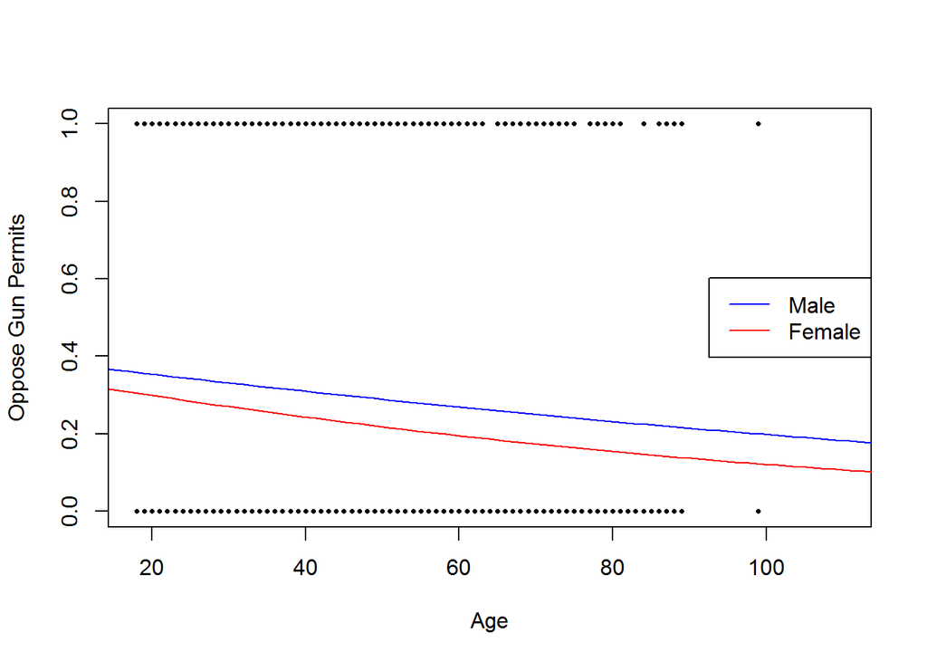

```r
plot(Oppose ~ age, data=GSSguns, pch=16, cex=0.5, xlim=c(18,110), xlab= "Age", ylab="Oppose Gun Permits")

curve(exp(b[1] + b[2]*x)/(1+exp(b[1] + b[2]*x)),from=0, to=188,  add=TRUE, col='Blue')

curve(exp(b[1]+b[3] + (b[2]+b[4])*x)/(1+exp(b[1]+b[3] + (b[2]+b[4])*x)),from=0, to=188,  add=TRUE, col='red')

legend("right", legend=c("Male", "Female"), col=c("Blue","red"), lty=1)
```

$\quad Y_{i} = \text{Oppose}$ $\quad X_{i1} = \text{Age}$ $\quad X_{i2} = \left\{\begin{array}{ll} 1, & \text{if Gender} = \text{Female} \\ 0, & \text{if Gender} = \text{Male} \end{array}\right.$

$$\underbrace{Y_i}_{Oppose}=\beta_0+\beta_1\underbrace{X_{i1}}_{Age}+\beta_2\underbrace{X_{i2}}_{Female}+\beta_3{X_{i1}X_{i2}}+\epsilon_i$$

$\hat{ Y }_{ i }=$ -0.4025554 + -0.00994 ${ X }_{ i1 }+$ -0.167038 ${ X }_{ i2 }+$ -0.0041847 ${ X }_{ i1 }{ X }_{ i2 }$

$$H_0: \beta_3 = 0 \\
H_a: \beta_3 \neq 0$$

### Interpretation

1. For males, the effect of `age` on the odds of opposing gun permits is $e^{-0.00994} = 0.9901092$ for every one year increase in age. This means there is a 1% drop in the odds of opposing gun permits for every year older.
2. Females are not significatly different than males.